# Assignment 3

# We decide to use the log-level model, because from the previous graphs we can see that many points of “Price” are intensively on the left side of the graph, and the result of using the level-level regression model would not be ideal (we have tested and compared with the two models to verify this idea.). Then we add the relevant variables. One point to notice is that we have a few assumptions in the part of “Interaction term” like “Type and Rooms”, “Distance and Rooms” and “Type and Distance”. Each assumption has their own reasonable part. Finally, we decide “Type and Rooms” as the best “Interaction term” by test. It is because that “Unit” are usually located close to the city center, and one more bedroom will have a greater impact on housing price than “Townhouse” and “House”. Moreover, each independent variable of this model is significant.

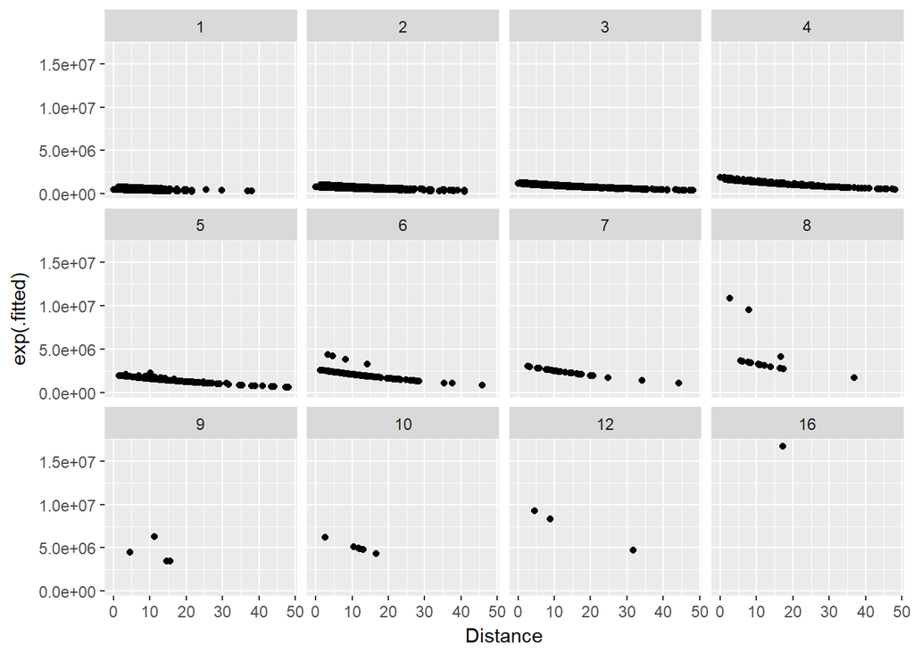

```r
mod1 <- augment(model_1,shadow2)

ggplot(mod1, aes(x=Distance)) +
  geom_point(aes(y=exp(.fitted)))+
  facet_wrap(~Rooms)
```

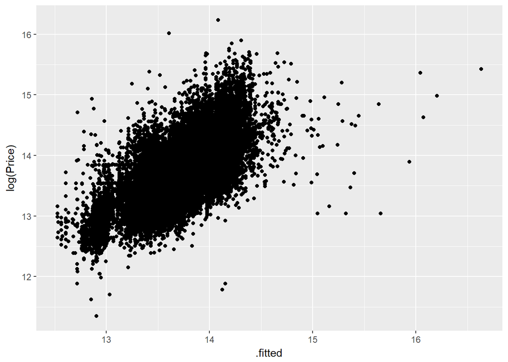

```r
ggplot(mod1, aes(x=.fitted, y=log(Price))) +
  geom_point()
```

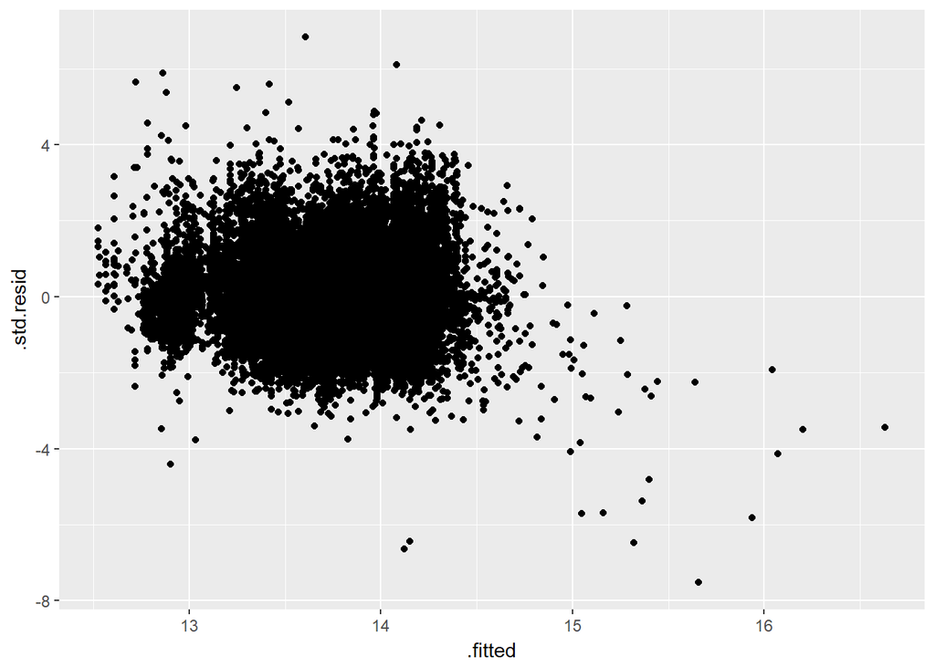

```r
ggplot(mod1, aes(x=.fitted, y=.std.resid)) +
  geom_point()
```